# Tennessee Consolidated Retirement System (TCRS): Modeling approach and simulation results

# 1 **Overview of key risk-sharing features**

Key policy features:

1. **DB-DC hybrid plan**. New hires after July 1, 2014 participate in a DB-DC hybrid plan.
   - DB component: ERC rate = 4%, EEC rate = 5%; 1% benefit factor
   - DC component: ERC rate = 5%, EEC rate = 2%
2. **Cost control provisions**.
   - The ADC rate shall not exceed 4% of payroll; the UAAL shall not exceed 12.5% of the five-year average of the state’s long-term indebtedness.
   - The state has established a stabilization reserve account and plans to contribute to the stabilization reserve account when the actuarially determined contribution rate is less than 4% of payroll.
   - If the control provisions are exceeded, the adjustments will automatically occur in the following sequence:
     1. Utilize funds in the stabilization reserve, if any
     2. Reduce or suspend the 3% retiree COLA benefit
     3. Shift some or all of the employer contributions from the defined contribution plan to the hybrid defined benefit plan
     4. Increase employee contributions by 1% of salary
     5. Reduce future service accrual below 1%
     6. Freeze the plan, no future service accrual
   - When the employer cost is restored to 4% and the unfunded liabilities do not exceed the maximum level, then the adjustments previously made are restored on a prospective basis. The sequence is in reverse order.

# 2 **Summary of modeling approach**

## 2.1 Policy scenarios

To examine the impact of the TCRS risk-sharing features on plan costs, funded status, and member benefit, we run the simulation under the following three policy scenarios.

1. **TCRS policy: hybrid plan with cost control provisions**
   - Currently the model incorporates the stabilization reserve and cost control adjustments 1-4.
   - The cost control provision for limit of UAAL is not incorporated in the model.
2. **Hybrid plan with no TCRS cost control features**
   - The same as 1 except for the TCRS stabilization reserve and cost control provisions.
3. **A pure DB plan similar to the DB component of TCRS hybrid plan, but with 2% benefit factor**
   - This DB plan is about twice as large as the DB component of the TCRS hybrid plan.

## 2.2 Investment return scenarios

1. Deterministic returns of 7.25% in 2019 and 2020. Stochastic after 2020: 7.25% expected mean return, 12% standard deviation. This is just for purposes of initial analysis. Will be replaced by scenarios and capital market assumptions provided by Pew.

## 2.3 Model assumptions and Simplifications

- Currently only the sub-plan for teachers is modeled. Will model the sub-plan for other employees in later versions.
- Benefit rules for the sub-plan for teachers:
  - Normal retirement requirement: age >= 60 or age + years of service >= 90
  - Benefit factor: 1% per year of service
- Key valuation methods and assumptions:
  - Discount rate: 7.25%
  - Cost method: EAN
  - Asset smoothing: 10 years with a +-20% corridor
  - Amortization of UAAL: 20-year level-dollar closed amortization

# 3 **Simulation results**

## 3.1 Summary of investment return scenarios

Please note that investment return percentile points won’t correspond exactly with percentile points for employer contributions or other concepts. For example, the 10th percentile for the long-run investment return won’t occur at the same simulation as the 10th percentile for the PV of employer contributions.

Distribution of 30-year compound annual returns

2020-2049; percentiles of 1,000 runs

| 90th | 75th | 50th | 25th | 10th |
| --- | --- | --- | --- | --- |
| 10.0% | 8.8% | 7.2% | 5.9% | 4.6% |

## 3.2 Analysis of contributions

**Note:**

- **Throughout this document, employer contributions include employer contributions to the stabilization reserve account.**

### 3.2.1 Distribution of long-term costs (Cost components add up)

Making the cost components add up to the PV of total contribution with terminal UAAL:

- Values in all tables (except the two “as % of AL” tables) are scaled using the 50th percentile value under the “Hybrid; 1% DB factor; Cost control” policy, which is set to 100.
- To make cost components add up, we also need to make sure that for each policy-percentile combination, the values across all component tables are from the same single simulation trial. For each policy, the simulation trials are selected based on percentiles of “PV of total contribution plus terminal UAAL”. Thus, the percentiles in the cost component tables (2 - 4) refer to the percentiles of “PV of total contribution plus UAAL”, not the percentiles of the component variables themselves.

(Click tabs below to show tables)

#### PV of total contribution with terminal UAAL

Distribution of 30-year present value of total contribution plus terminal UAAL

| Policy | 99th | 90th | 75th | 50th | 25th | 10th |
| --- | --- | --- | --- | --- | --- | --- |
| Hybrid; 1% DB factor; Cost control | 113.5 | 107.9 | 104.8 | 100.0 | 93.2 | 84.4 |
| Hybrid; 1% DB factor; No cost control | 107.6 | 98.8 | 93.2 | 84.8 | 75.5 | 65.8 |
| DB; 2% DB factor; No cost control | 123.4 | 106.2 | 95.2 | 78.8 | 60.1 | 41.1 |

#### PV of employer contribution

Distribution of 30-year present value of ERC

| Policy | 99th | 90th | 75th | 50th | 25th | 10th |
| --- | --- | --- | --- | --- | --- | --- |
| Hybrid; 1% DB factor; Cost control | 56.8 | 56.8 | 56.8 | 56.8 | 56.8 | 56.8 |
| Hybrid; 1% DB factor; No cost control | 54.0 | 44.8 | 41.6 | 44.4 | 41.6 | 36.2 |
| DB; 2% DB factor; No cost control | 73.3 | 67.1 | 49.2 | 54.5 | 32.9 | 34.1 |

#### PV of employee contribution

Distribution of 30-year present value of EEC

| Policy | 99th | 90th | 75th | 50th | 25th | 10th |
| --- | --- | --- | --- | --- | --- | --- |
| Hybrid; 1% DB factor; Cost control | 44.2 | 44.2 | 44.2 | 44.2 | 44.2 | 44.2 |
| Hybrid; 1% DB factor; No cost control | 44.2 | 44.2 | 44.2 | 44.2 | 44.2 | 44.2 |
| DB; 2% DB factor; No cost control | 31.5 | 31.5 | 31.5 | 31.5 | 31.5 | 31.5 |

#### PV of terminal UAAL

Distribution of present value of terminal UAAL (year 30)

| Policy | 99th | 90th | 75th | 50th | 25th | 10th |
| --- | --- | --- | --- | --- | --- | --- |
| Hybrid; 1% DB factor; Cost control | 12.5 | 7.0 | 3.9 | −1.0 | −7.8 | −16.5 |
| Hybrid; 1% DB factor; No cost control | 9.5 | 9.8 | 7.4 | −3.8 | −10.3 | −14.6 |
| DB; 2% DB factor; No cost control | 18.5 | 7.6 | 14.5 | −7.3 | −4.4 | −24.5 |

Note: negative values are surplus

#### Terminal UAAL as % of AL

```r
tbl_UAAL_AL.v2
```

Distribution of terminal UAAL (year 30)

% of terminal AL

| Policy | 99th | 90th | 75th | 50th | 25th | 10th |
| --- | --- | --- | --- | --- | --- | --- |
| Hybrid; 1% DB factor; Cost control | 33.6 | 18.7 | 10.3 | −2.6 | −21.0 | −44.4 |
| Hybrid; 1% DB factor; No cost control | 25.5 | 26.4 | 20.0 | −10.2 | −27.7 | −39.3 |
| DB; 2% DB factor; No cost control | 25.5 | 10.4 | 20.0 | −10.0 | −6.0 | −33.8 |

#### PV of terminal balance of reserve

```r
tbl_pvReserve.v2
```

Distribution of present value of terminal balance of reserve (year 30)

| Policy | 99th | 90th | 75th | 50th | 25th | 10th |
| --- | --- | --- | --- | --- | --- | --- |
| Hybrid; 1% DB factor; Cost control | 4.1 | 5.3 | 10.0 | 14.2 | 26.8 | 31.6 |
| Hybrid; 1% DB factor; No cost control | 0.0 | 0.0 | 0.0 | 0.0 | 0.0 | 0.0 |
| DB; 2% DB factor; No cost control | 0.0 | 0.0 | 0.0 | 0.0 | 0.0 | 0.0 |

Note: negative values are surplus

#### Terminal balance of reserve as % of AL

```r
tbl_reserveAL.v2
```

Distribution of terminal balance of reserve fund (year 30)

% of terminal AL

| Policy | 99th | 90th | 75th | 50th | 25th | 10th |
| --- | --- | --- | --- | --- | --- | --- |
| Hybrid; 1% DB factor; Cost control | 11.1 | 14.2 | 26.8 | 38.0 | 72.1 | 85.0 |
| Hybrid; 1% DB factor; No cost control | 0.0 | 0.0 | 0.0 | 0.0 | 0.0 | 0.0 |
| DB; 2% DB factor; No cost control | 0.0 | 0.0 | 0.0 | 0.0 | 0.0 | 0.0 |

### 3.2.2 Distribution of long-term costs (Cost components DO NOT add up)

Values in all tables (except the two “as % of AL” tables) are scaled using the 50th percentile value under the “Hybrid; 1% DB factor; Cost control” policy, which is set to 100.

But the cost components do not add up to the “pv of total contribution plus terminal UAAL” because in each table the percentiles are calculated based on the variable in that table. So for each policy-percentile combination, the values across the component tables may come from different simulation trials.

(Click tabs below to show tables)

#### PV of total contribution with terminal UAAL

Distribution of 30-year present value of total contribution plus terminal UAAL

| Policy | 99th | 90th | 75th | 50th | 25th | 10th |
| --- | --- | --- | --- | --- | --- | --- |
| Hybrid; 1% DB factor; Cost control | 113.4 | 107.9 | 104.8 | 100.0 | 93.1 | 84.5 |
| Hybrid; 1% DB factor; No cost control | 107.6 | 98.8 | 93.2 | 84.8 | 75.4 | 65.9 |
| DB; 2% DB factor; No cost control | 123.3 | 106.1 | 95.2 | 78.8 | 60.1 | 41.5 |

#### PV of employer contribution

Distribution of 30-year present value of ERC

| Policy | 99th | 90th | 75th | 50th | 25th | 10th |
| --- | --- | --- | --- | --- | --- | --- |
| Hybrid; 1% DB factor; Cost control | 56.8 | 56.8 | 56.8 | 56.8 | 56.8 | 56.8 |
| Hybrid; 1% DB factor; No cost control | 54.1 | 49.3 | 45.5 | 41.7 | 38.1 | 36.0 |
| DB; 2% DB factor; No cost control | 73.6 | 64.3 | 56.6 | 48.2 | 38.6 | 31.0 |

#### PV of employee contribution

Distribution of 30-year present value of EEC

| Policy | 99th | 90th | 75th | 50th | 25th | 10th |
| --- | --- | --- | --- | --- | --- | --- |
| Hybrid; 1% DB factor; Cost control | 44.2 | 44.2 | 44.2 | 44.2 | 44.2 | 44.2 |
| Hybrid; 1% DB factor; No cost control | 44.2 | 44.2 | 44.2 | 44.2 | 44.2 | 44.2 |
| DB; 2% DB factor; No cost control | 31.5 | 31.5 | 31.5 | 31.5 | 31.5 | 31.5 |

#### PV of terminal UAAL

Distribution of present value of terminal UAAL (year 30)

| Policy | 99th | 90th | 75th | 50th | 25th | 10th |
| --- | --- | --- | --- | --- | --- | --- |
| Hybrid; 1% DB factor; Cost control | 7.0 | 7.0 | 3.9 | −0.9 | −7.8 | −16.4 |
| Hybrid; 1% DB factor; No cost control | 7.0 | 7.0 | 3.9 | −0.9 | −7.8 | −16.4 |
| DB; 2% DB factor; No cost control | 13.8 | 13.8 | 7.9 | −1.1 | −11.7 | −25.2 |

Note: negative values are surplus

#### Terminal UAAL as % of AL

```r
tbl_UAAL_AL.v1
```

Distribution of terminal UAAL (year 30)

% of terminal AL

| Policy | 99th | 90th | 75th | 50th | 25th | 10th |
| --- | --- | --- | --- | --- | --- | --- |
| Hybrid; 1% DB factor; Cost control | 33.6 | 18.7 | 10.4 | −2.5 | −21.0 | −44.1 |
| Hybrid; 1% DB factor; No cost control | 33.6 | 18.7 | 10.4 | −2.5 | −21.0 | −44.1 |
| DB; 2% DB factor; No cost control | 33.7 | 19.0 | 10.8 | −1.5 | −16.1 | −34.8 |

#### PV of terminal balance of reserve

```r
tbl_pvReserve.v1
```

Distribution of present value of terminal balance of reserve (year 30)

| Policy | 99th | 90th | 75th | 50th | 25th | 10th |
| --- | --- | --- | --- | --- | --- | --- |
| Hybrid; 1% DB factor; Cost control | 42.9 | 29.0 | 22.1 | 14.9 | 8.5 | 3.9 |
| Hybrid; 1% DB factor; No cost control | 0.0 | 0.0 | 0.0 | 0.0 | 0.0 | 0.0 |
| DB; 2% DB factor; No cost control | 0.0 | 0.0 | 0.0 | 0.0 | 0.0 | 0.0 |

Note: negative values are surplus

#### Terminal balance of reserve as % of AL

```r
tbl_reserveAL.v1
```

Distribution of terminal balance of reserve fund (year 30)

% of terminal AL

| Policy | 99th | 90th | 75th | 50th | 25th | 10th |
| --- | --- | --- | --- | --- | --- | --- |
| Hybrid; 1% DB factor; Cost control | 115.2 | 77.8 | 59.4 | 39.9 | 22.7 | 10.5 |
| Hybrid; 1% DB factor; No cost control | 0.0 | 0.0 | 0.0 | 0.0 | 0.0 | 0.0 |
| DB; 2% DB factor; No cost control | 0.0 | 0.0 | 0.0 | 0.0 | 0.0 | 0.0 |

### 3.2.3 Short-term volatility of costs

#### Risk of sharp ERC increase

This graph shows the probability that the ERC rate will rise by more than 10 percentage points within any 5-year period leading up to the current year. For example, in 2035 it shows the probability that the ERC rose by 10 percentage points or more in any prior 5-year period (2020-2024, 2021-2025, …, 2031-2035). This is designed to show whether the government was likely to face a sharp increase in contribution costs in a short period of time, during the period examined.

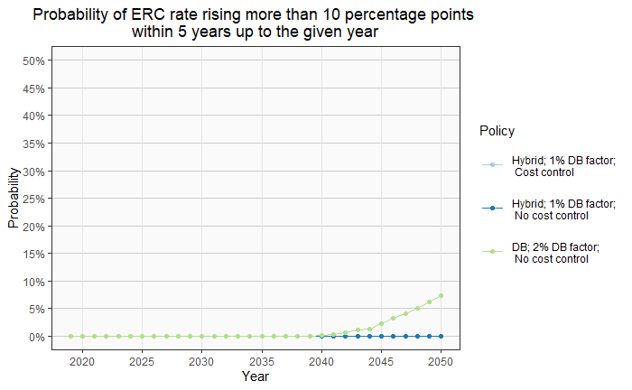

#### Risk of sharp EEC increase

This graph shows the probability that the EEC rate will rise by more than 5 percentage points within any 5-year period leading up to the current year. For example, in 2035 it shows the probability that the EEC rose by 5 percentage points or more in any prior 5-year period (2020-2024, 2021-2025, …, 2031-2035). This is designed to show whether the plan member was likely to face a sharp increase in contribution costs in a short period of time, during the period examined. Note that we use a 5-percentage-point change for the EEC and a 10-percentage-point change for the ERC, on the belief that individuals may consider a smaller sharp change to their take home pay to be quite significant.

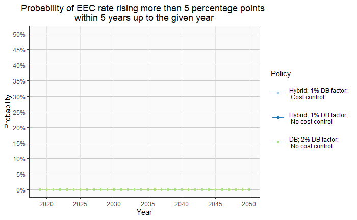

## 3.3 **Analysis of funded status**

Funded ratios in the following risk measures do not take the stabilization reserve into account.

- Chance that funded ratio will fall below 80%
- Chance that funded ratio will fall below 60%
- Chance of the plan being at least 100% funded in the given year

### Risk of low funded ratio up to a given year

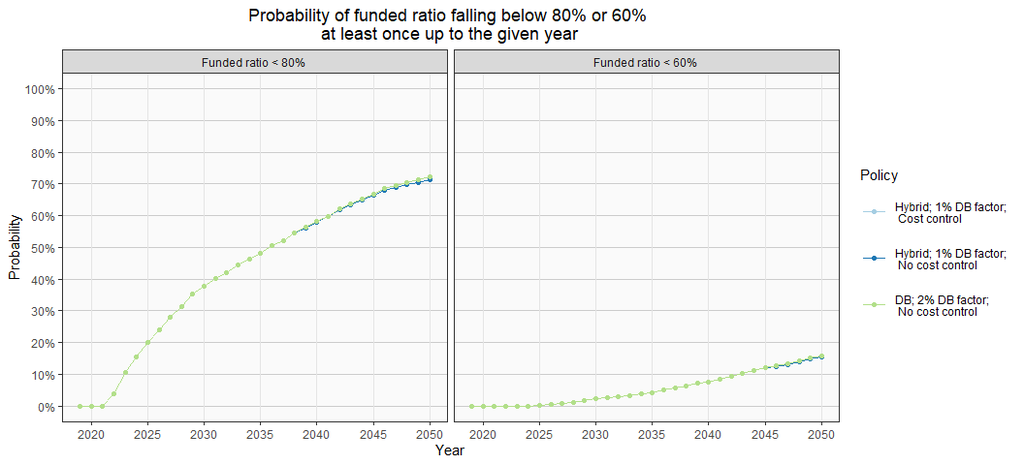

### Risk of low funded ratio in a given year

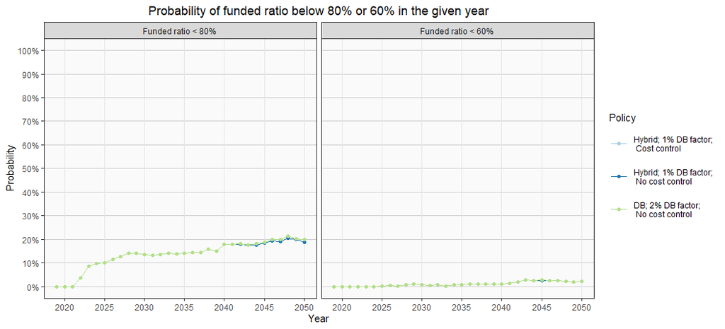

### Probability of full funding

Note that the sharp drop in the probability of full funding in year 4 is not because of an assumed deterministic loss. Rather, it is bacause the plan starts fully funded in 2019 and deterministic returns of 7.25% (plan assumption) are assumed in the first two years and stochastic returns starts in year 3, after which there is an about 50% chance the funded ratio will fall below 100%.

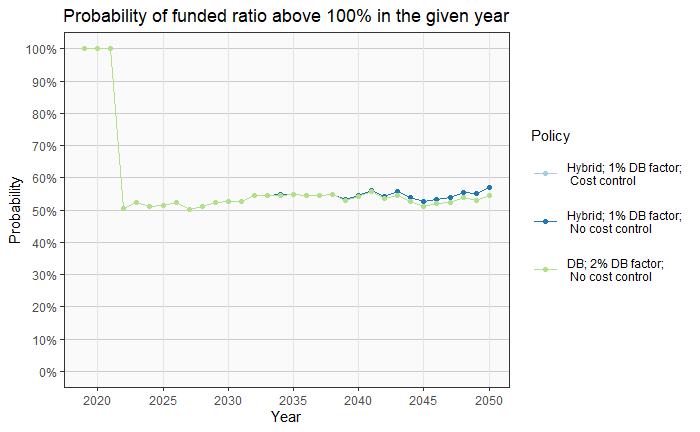

## 3.4 **Analysis of member benefit**

### 3.4.1 New retirees in 2020

Cohort examined:

- Joined the plan at age 25 in 1985
- Start receiving benefit at age 60 in 2020
- Live to age 90 (30 years in retirement)

Assumptions on DC benefits

- For hybrid plans, it is assumed that the DC balance upon retirement is equal to the present value of future DB benefits. Thus, the uncertainty in the accumulation phase of DC benefits is not included in this section.
- Annual withdrawals from the DC account are assumed to be 6.7% of the DC balance. 6.7% is the withdrawal rate that makes the hybrid plans and the pure DB plan have the same benefit payment in first year of retirement, and it makes the comparison across policies easier. We will conduct sensitivity analysis to see the impact the withdrawal rate assumption.
- For hybrid plans, the present value of benefits include the present value of remaining DC balance at age 90.If the return assumption is always met and the withdrawal rate is 6.7% as assumed above, the nominal value of the DC balance only shrinks slightly from age 60 to 90.

#### Distribution of present value of benefit

Distribution of 30-year present value of benefit

For members who retire at age 60 with 35 years of service in 2020

| Policy | 90th | 75th | 50th | 25th | 10th | 1th |
| --- | --- | --- | --- | --- | --- | --- |
| Hybrid; 1% DB factor; Cost control | 1,921 | 1,743 | 1,585 | 1,462 | 1,377 | 1,248 |
| Hybrid; 1% DB factor; No cost control | 1,921 | 1,743 | 1,585 | 1,462 | 1,377 | 1,249 |
| DB; 2% DB factor; No cost control | 1,633 | 1,633 | 1,633 | 1,633 | 1,633 | 1,633 |

Note: starting benefit is normalized to $100; assumed withdrawal rate from DC balance: 6.7%; benefits of hybrid plans also include the present value of remaining DC balances at age 90

#### Distribution of replacement rate at age 75

Distribution of replacement rate at age 75

For members who retire at age 60 with 35 years of service in 2020

| Policy | 99th | 90th | 75th | 50th | 25th | 10th | 1th |
| --- | --- | --- | --- | --- | --- | --- | --- |
| Hybrid; 1% DB factor; Cost control | 86% | 72% | 64% | 57% | 51% | 46% | 41% |
| Hybrid; 1% DB factor; No cost control | 86% | 72% | 64% | 57% | 51% | 46% | 41% |
| DB; 2% DB factor; No cost control | 65% | 65% | 65% | 65% | 65% | 65% | 65% |

Note: benefits at age 75 are adjusted for inflation; assumed inflation = 2.75%; assumed withdrawal rate from DC balance: 6.7%

### 3.4.2 New employees in 2020

Cohort examined:

- Joined the plan at age 25 2020
- Start receiving benefit at age 60 in 2055

#### Total (DB + DC) replacement rate at age 60

Distribution of total (DB + DC) replacement rate at age 60

| Policy | 90th | 75th | 50th | 25th | 10th | 1th |
| --- | --- | --- | --- | --- | --- | --- |
| Hybrid; 1% DB factor; Cost control | 79% | 70% | 61% | 53% | 49% | 42% |
| Hybrid; 1% DB factor; No cost control | 79% | 70% | 61% | 53% | 49% | 44% |
| DB; 2% DB factor; No cost control | 65% | 65% | 65% | 65% | 65% | 65% |

Assumed withdrawal rate from DC balance: 6.7%.

#### Replacement rate of DC benefit at age 60

Distribution of DC replacement rate at age 60

| Policy | 90th | 75th | 50th | 25th | 10th | 1th |
| --- | --- | --- | --- | --- | --- | --- |
| Hybrid; 1% DB factor; Cost control | 46% | 38% | 28% | 21% | 16% | 10% |
| Hybrid; 1% DB factor; No cost control | 46% | 38% | 28% | 21% | 17% | 11% |
| DB; 2% DB factor; No cost control | 0% | 0% | 0% | 0% | 0% | 0% |

Assumed withdrawal rate from DC balance: 6.7%.